# The Wreck of the Titan Sentiment Analysis

B.M Njuguna

2023-05-16

The **Wreck of the Titan** is a novel that was written by American writer **Morgan Robertson** (Robertson (1912)) . It was first published in 1898, and then later republished in 1912. The fictional story is about a ship called *Titan* which sinks in the North Atlantic Ocean, after hitting a iceberg, resulting to loss of most of its passengers and crew. This novel was written 14 yeas before the sinking of the RMS Titanic ship in 1912. The similarities between the fictional story and the actual event of the sinking of the ship in 1912 have led to much speculations about whether Robertson’s may have inspired or even predicted the Titanic Disaster.

Robertson, Morgan. 1912. *The Wreck of the Titan, or, Futility*.

Robertson describes the ship as a large unsinkable passenger liner with many of the features similar to the titanic (Donnelly (2000)). The ship in the fictional story travels at high speed in a sea filled with icebergs which is similar to the Titanic ship. The book’s description about the sinking of the ship have similarities with the actual description of the sinking of the ship. Also, in the book, there are challenges such as lack of enough life boats and confusion among the crew which are similar to the actual sinking of the ship. The books prescient warning about the dangers of the overconfidence in the face of natural disasters.

Donnelly, Fred. 2000. “The Titanic’s Humanist Paradox.”

**Sentiment analysis** is a technique used to extract, identify and/or identify subjective information from text or novel (Mejova (2009)). It is a sub-field of Natural Language Processing that is also used to identify whether the sentiment of a text, novel or document is positive, negative or neutral. Sentiment analysis started in the 1950s with simple use of lexical (lexicons) and heuristics database to identify and classify words as positive and negative. However, these early attempts were limited by their accuracy and effectiveness.

Mejova, Yelena. 2009. “Sentiment Analysis: An Overview.”

Lexicons are dictionaries or lists of words and their meanings, often used in natural language processing and computational linguistics. They can also include additional information about words such as part-of-speech, pronunciation, and syntactic behavior. Lexicons can be created manually or automatically generated from large text corpora.

The field of sentiment analysis advanced significantly at around 2000 with the invention of more sophisticated machine learning algorithms and the availability of large amounts of labelled data for training and testing (Mäntylä, Graziotin, and Kuutila (2018).

1. The objective of this study was to examine the general sentiment of the novel *The wreck of the titanic*.
2. Examine the change of emotions across the trajectory of the novel.
3. Compare the results of different performances of the lexicons used.

Basically, sentiment analysis method was used in this study. The study was done using *R statistical package*. Specifically, lexicons in R were used to obtain the sentiment of the novels.

First, The R package *gutenbergr* was used to download the novel in R. Then the R package *tidytext* was used to clean and put the text in the novel in the tidy format easier analysis. *tidytext* was also used to download the lexicons for the sentiment analysis. The three lexicons used for the analysis were as listed below;

- **AFINN**
- **Bing**
- **NRC**

All three lexicons are based on unigrams, i.e., single words. These lexicons contain many English words and the words are assigned scores for positive/negative sentiment, and also possibly emotions like joy, anger, sadness, and so forth. The **NRC** lexicon **categorizes words in a binary fashion (“yes”/“no”) into categories of positive**, **negative, anger, anticipation, disgust, fear, joy, sadness, surprise, and trust**. The **Bing** lexicon **categorizes words in a binary fashion into positive and negative categories**. The **AFINN** lexicon **assigns words with a score that runs between -5 and 5, with negative** **scores indicating negative sentiment and positive scores indicating positive sentiment**.

The novel was downloaded in R and the glimpse of the first part of the first page is shown below;

```r
# Checking which id is the novel
# Foirst we llok up for novels written by Robertson

library(gutenbergr)
robertson_books <- gutenberg_works(author == "Robertson, Morgan")

# Downloading the novel after identifyig the ID of the novel

titanic <- gutenberg_download(24880)
cat(head(titanic$text, c(100)), sep = "\n")
```

```
   THE WRECK OF THE
         TITAN

     OR, FUTILITY

          BY

   MORGAN ROBERTSON


   AUTOGRAPH EDITION
     PUBLISHED BY
  McCLURE'S MAGAZINE
          AND
 METROPOLITAN MAGAZINE




 Copyright, 1898, by
 M. F. MANSFIELD

 Copyright, 1912, by
 MORGAN ROBERTSON

 _All rights reserved_


 THE QUINN & BODEN CO. PRESS
 RAHWAY, N. J.




CONTENTS


 THE WRECK OF THE TITAN             1

 THE PIRATES                       70
```

[output cut: 44 more lines]

```
From the bridge, engine-room, and a dozen places on her deck the
ninety-two doors of nineteen water-tight compartments could be closed in
half a minute by turning a lever. These doors would also close
automatically in the presence of water. With nine compartments flooded
the ship would still float, and as no known accident of the sea could
possibly fill this many, the steamship _Titan_ was considered
practically unsinkable.

Built of steel throughout, and for passenger traffic only, she carried
no combustible cargo to threaten her destruction by fire; and the
immunity from the demand for cargo space had enabled her designers to
discard the flat, kettle-bottom of cargo boats and give her the sharp
dead-rise--or slant from the keel--of a steam yacht, and this improved
her behavior in a seaway. She was eight hundred feet long, of seventy
thousand tons' displacement, seventy-five thousand horse-power, and on
```

Then the nrc, AFFIN and bing weren imported and the glimpse of the first few rows of the different lexicons are as shown below. The following is the nrc lexicons

```r
library(tidytext)
get_sentiments("nrc") %>%
  head() %>%
  kable()
```

| word | sentiment |
| --- | --- |
| abacus | trust |
| abandon | fear |
| abandon | negative |
| abandon | sadness |
| abandoned | anger |
| abandoned | fear |

The following is the AFINN lexicon. As mentioned above, the AFINN lexicon scores the sentiments from -5 to 5, with the most negative sentiment being -5 and the most positive being 5

```r
get_sentiments("afinn") %>%
  head() %>%
  kable()
```

| word | value |
| --- | --- |
| abandon | -2 |
| abandoned | -2 |
| abandons | -2 |
| abducted | -2 |
| abduction | -2 |
| abductions | -2 |

The lexicon bing lexicon is as shown below;

```r
get_sentiments("bing") %>%
  head() %>%
  kable()
```

| word | sentiment |
| --- | --- |
| 2-faces | negative |
| abnormal | negative |
| abolish | negative |
| abominable | negative |
| abominably | negative |
| abominate | negative |

The most common words were identified and visualized as follows;

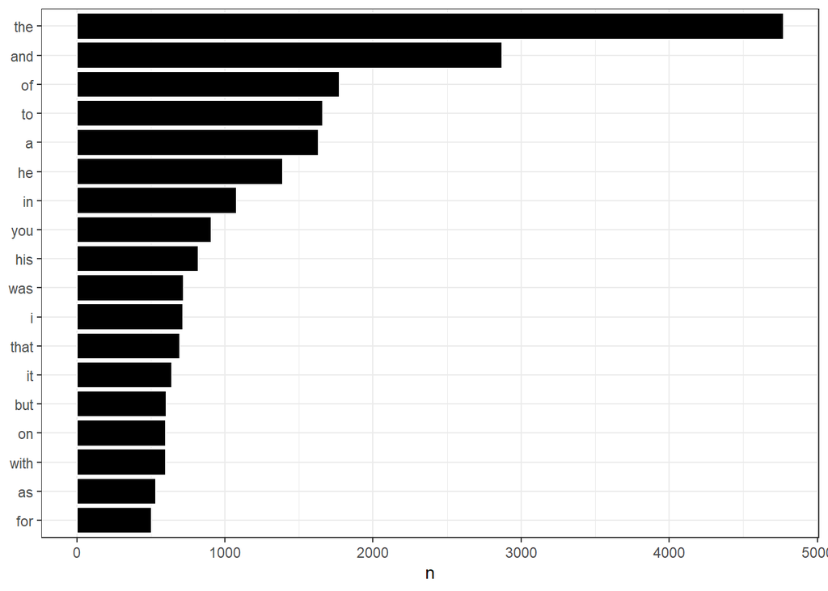

```r
titanic <- titanic %>%
  mutate(linenumber = row_number(),
         chpater = cumsum(str_detect(text, regex("^chapter", ignore_case = TRUE))))


titanic <- titanic %>%
  unnest_tokens(word, text)


titanic %>%
  count(word, sort = TRUE) %>%
  filter(n > 500 ) %>%
  mutate(word = reorder(word, n)) %>%
  ggplot(aes(word, n)) +
  geom_col(fill = "black", col = "white") +
  xlab(NULL) +
  coord_flip() +
  theme(axis.line = element_line()) +
  theme_bw()
```

The word `the` was the most used word in the novel, followed by the word `and`. However these words are usually classified as stop words in sentiment analysis and hence showing the frequency of their usage in a novel do not have much interpretation. Thus, the stop words were removed and the following plot was obtained.

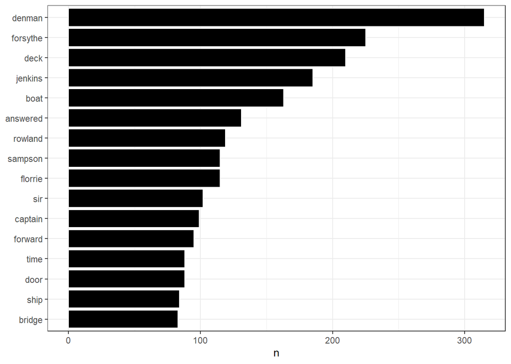

```r
data("stop_words")
titanic2 <- titanic %>%
  anti_join(stop_words)


titanic2 %>%
  count(word, sort = TRUE) %>%
  filter(n > 80 ) %>%
  mutate(word = reorder(word, n)) %>%
  ggplot(aes(word, n)) +
  geom_col(fill = "black", col = "white") +
  xlab(NULL) +
  coord_flip() +
  theme(axis.line = element_line()) +
  theme_bw()
```